# Unit 02 assignment

Stacey Smith

# 1. Put the following questions into RMarkdown as headers (or subheaders if youre making question numbers headings). Be sure to answer the questions underneath each header.

## What is a basic workflow for reproducible research?

1. Data Gathering
2. Data Analysis
3. Results Presentation

## What are five practical tips for making research reproducible?

1. Document everything!
2. Everything is a (text) file.
3. All files should be human readable.
4. Explicitly tie your files together.
5. Have a plan to organize, store, and make your files available.

## Give an example of how you might implement each tip.

1. Explain or comment every step of the process. In R run the sessionInfo command.
2. Make sure I save all my information in a text file.
3. Make sure I insert comments throughout my research.
4. I will use the commands in Table 2.1 to tie together my research files.
5. I will use GitHub.

## Which one of these do you think will be the most difficult?

Explicitly tie your files together.

# ——————————————————————————————————————————————

# 2. Download and complete air_hist.R code from the Files Tab on 2DS. You will build scatter plots using the plot function.

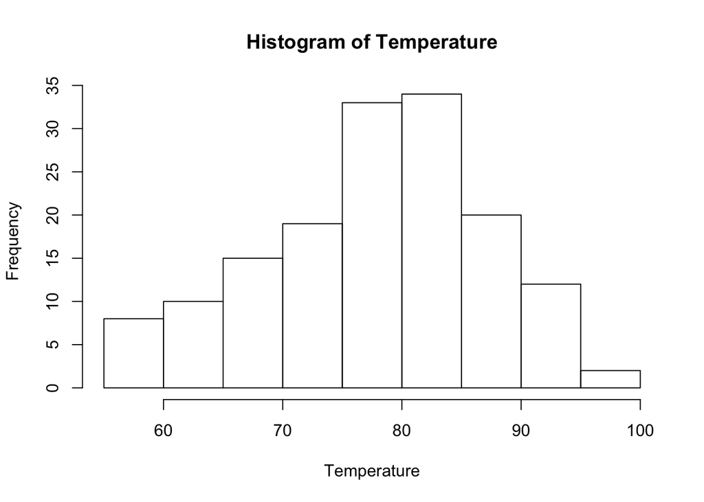

```r
# Take only Temp columns
Temperature <- airquality$Temp
hist(Temperature)
```

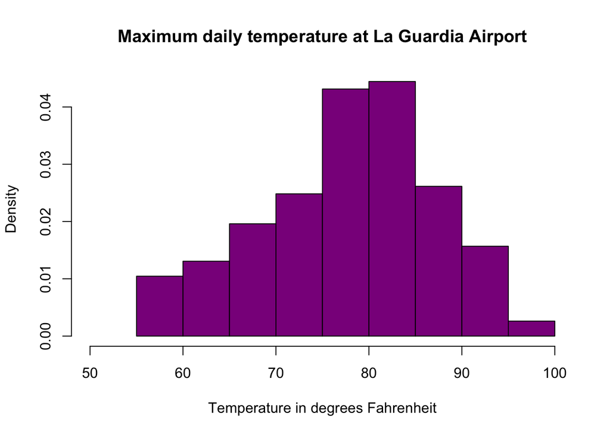

```r
# Histogram with added parameters
hist(Temperature,
     main="Maximum daily temperature at La Guardia Airport",
     xlab="Temperature in degrees Fahrenheit",
     xlim=c(50,100),
     col="darkmagenta",
     freq=FALSE
)
```

## Plots

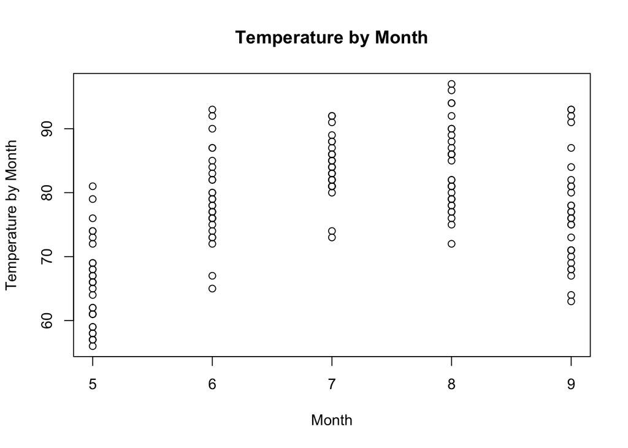

```r
#plot(pressure)
plot(x=airquality$Month, y=airquality$Temp,main = "Temperature by Month", xlab = "Month", ylab = "Temperature by Month")   # How are the Month and temperature measurements relate?
```

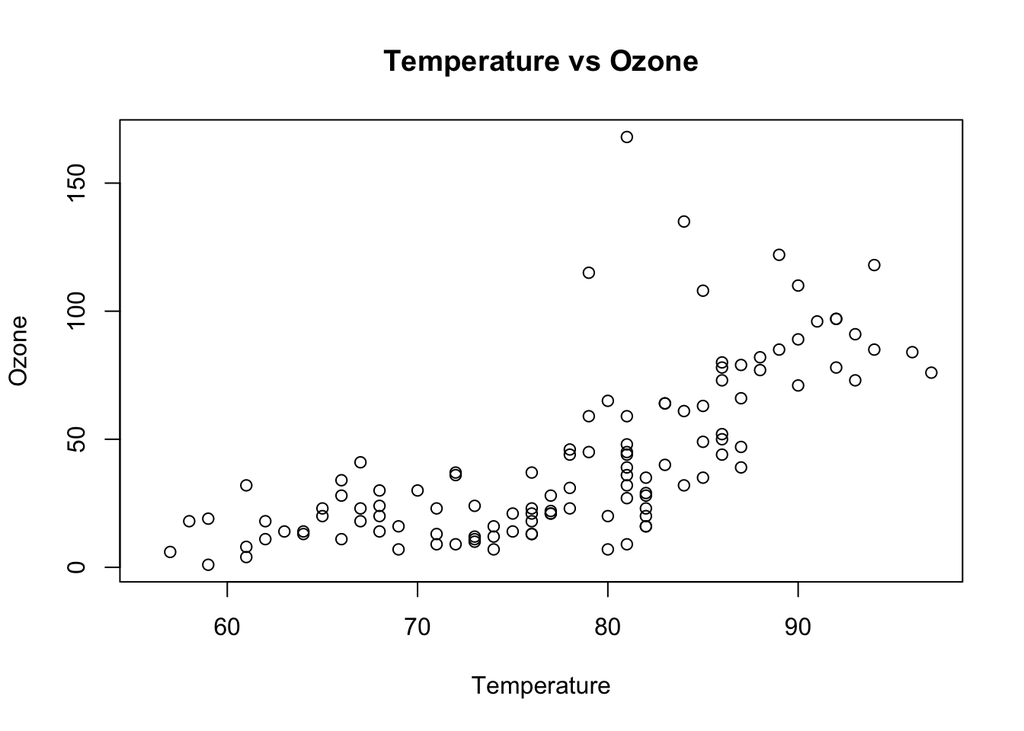

```r
plot(x=airquality$Temp, y=airquality$Ozone,main = "Temperature vs Ozone", xlab = "Temperature", ylab = "Ozone")   # How are the Ozone and temperature measurements relate?
```

# 3. Download and complete knit_cars.Rmd in the Files tab on 2DS.

```r
summary(cars)
```

```
##      speed           dist
##  Min.   : 4.0   Min.   :  2.00
##  1st Qu.:12.0   1st Qu.: 26.00
##  Median :15.0   Median : 36.00
##  Mean   :15.4   Mean   : 42.98
##  3rd Qu.:19.0   3rd Qu.: 56.00
##  Max.   :25.0   Max.   :120.00
```

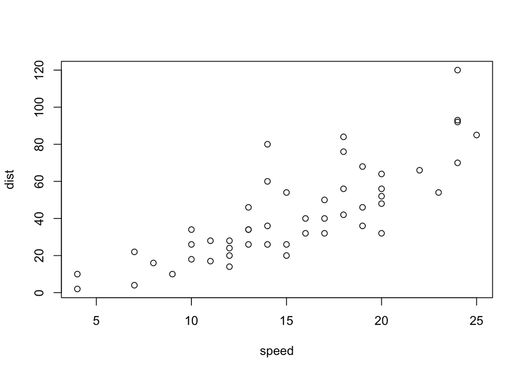

## Including Plots

```r
summary(pressure)
```

```
##   temperature     pressure
##  Min.   :  0   Min.   :  0.0002
##  1st Qu.: 90   1st Qu.:  0.1800
##  Median :180   Median :  8.8000
##  Mean   :180   Mean   :124.3367
##  3rd Qu.:270   3rd Qu.:126.5000
##  Max.   :360   Max.   :806.0000
```

You can also embed plots as default, for example:

[figure not shown]

```r
#plot(pressure, )
plot(x=pressure, main = "Pressure vs Temperature", xlab = "Pressure", ylab = "Temperature")   # Temperature vs Pressure?
```

Now flip it!

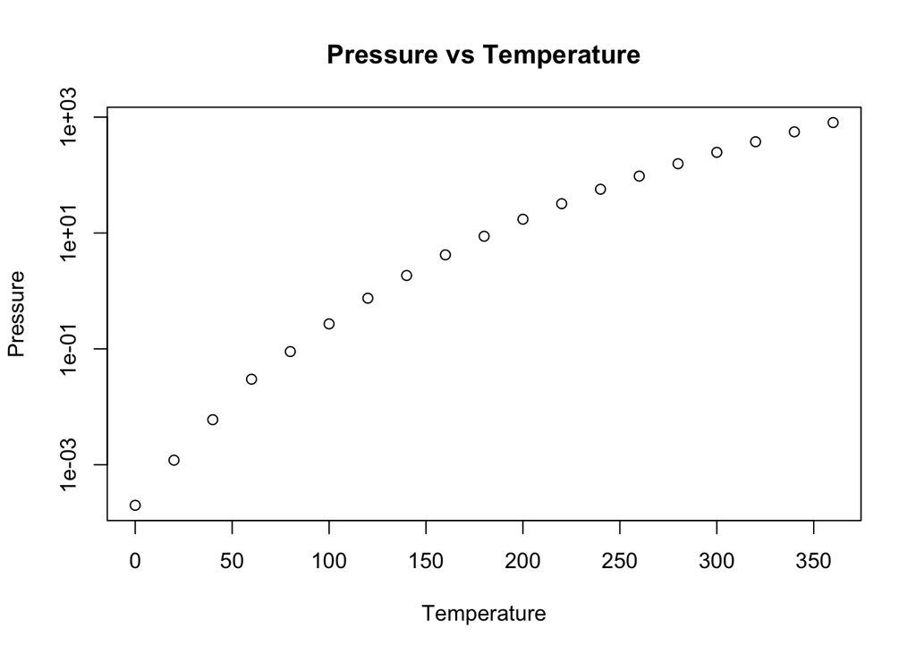

```r
plot(x=pressure, main = "Pressure vs Temperature", xlab = "Temperature", ylab = "Pressure",log="y")   # Pressure vs Temperature?
```